# Clustering (Part II)

Ryan Miller

## Clustering (continued)

- The last presentation introduced $k$-means clustering
  - $k$-means is very popular, but so are a number of other methods
  - One issue is that $k$-means is only well-defined when *all* of the variables are quantitative
- Today we will explore a couple of other clustering algorithms, and in doing we’ll see an approach to clustering categorical variables

## k-Medoids?

- In statistics, the mean is the most popular choice for summarizing a numeric variable
  - In some applications, the mean can be unduly influenced by outliers or skew, making it a poor representative of the variable’s “center”
- A robust alternative to the mean is the median, so why not use the median to form cluster centers?

## Partitioning Around Medoids (PAM)

- PAM is a clustering algorithm that searches for $k$ objects called **medoids** among the observed data-points
  - The algorithm starts with the medoids being chosen at random
  - Given a set of medoids, the other data-points assigned to the cluster defined by their nearest medoid
  - Then the algorithm performs a “swapping step”“, where it checks for improvements by switching the medoids
  - If a medoid is swapped, the other data-points are re-assigned, and the swapping step is repeated
  - The prior two steps happen iteratively until a solution is reached

## When to use PAM?

- Because the cluster centers in PAM are data-points themselves, the algorithm *only requires* a distance matrix!
  - We will later see that we can use PAM on data containing categorical variables (after constructing a suitable distance matrix)
- PAM is also more robust to outliers and skew than $k$-means, but its computation cost is greater and it can be more sensitive to the choice of initial cluster centers

```r
data("USArrests")
set.seed(123)
pm_std <- pam(scale(USArrests), k = 3)
km_std <- kmeans(scale(USArrests), centers = 3)
pm_std$medoids
```

```
##                   Murder    Assault   UrbanPop       Rape
## New Mexico     0.8292944  1.3708088  0.3081225  1.1603196
## Oklahoma      -0.2727580 -0.2371077  0.1699510 -0.1315342
## New Hampshire -1.3059321 -1.3650491 -0.6590781 -1.2525644
```

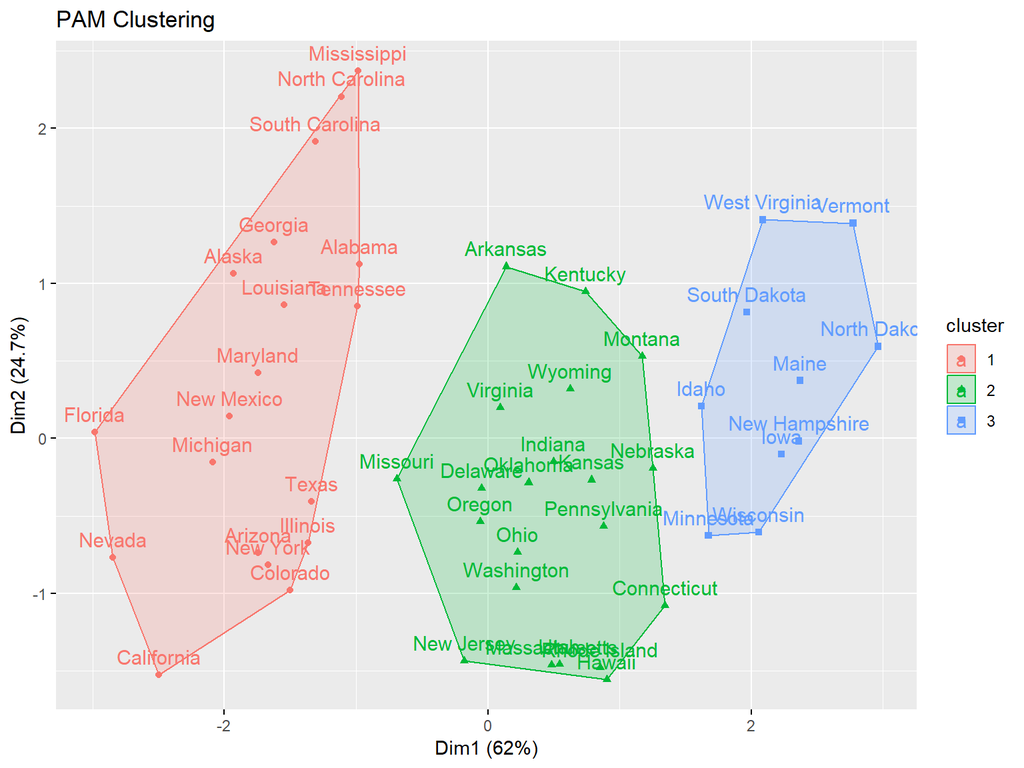

```r
fviz_cluster(pm_std) + labs(title = "PAM Clustering")
```

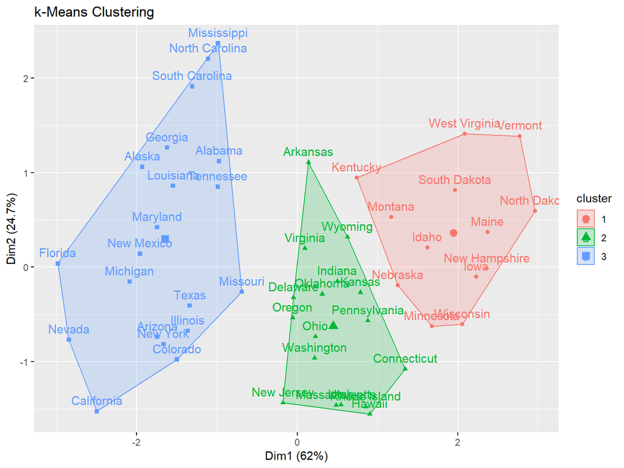

```r
fviz_cluster(km_std, data = scale(USArrests))  + labs(title = "k-Means Clustering")
```

## Hierarchical Clustering

- Both PAM and $k$-means are similar in nature, they iteratively consider partitions the data, re-evaluating a global objective function at each iteration
- An alternative would be to greedily aggregate (or separate) data-points, creating a tree-like structure known as a **dendrogram**
- The y-axis of the dendrogram is a measure of closeness

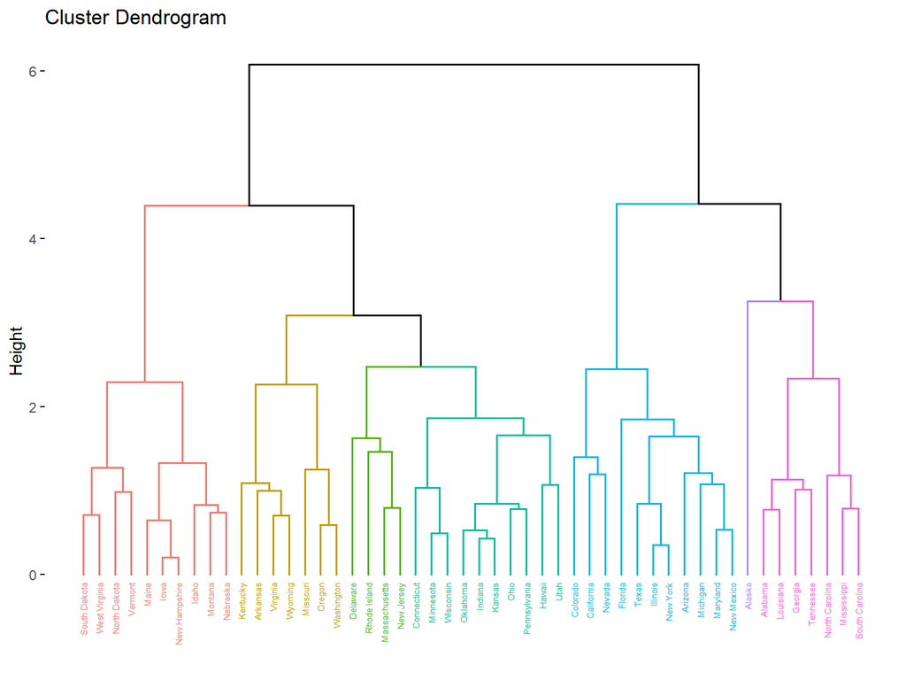

```r
d <- get_dist(scale(USArrests))
hc <- hclust(d)

fviz_dend(hc, cex = 0.4, h = 2.5)
```

- Iowa and New Hampshire are very close, you don’t have to go very far before both states share a cluster
- South Dakota and Iowa are modestly close, you have go to a height of ~2.5 to find a cluster containing both
- Iowa and South Carolina are very far, they are only clustered together once all of the data are in the same cluster